# final-project

2024-05-09

# BF 528 FINAL PROJECT

## PROJECT PROPOSAL

### 1.1 Introduction

In this project, I will perform a comprehensive analysis of RNAseq data derived from 6 samples, including 3 control (CTL) and 3 knock-out (KO) samples from a human source. The primary objective is to conduct a basic differential expression analysis comparing the CTL and KO conditions. Additionally, I will perform quality control (QC) at both the read and alignment levels, followed by exploratory data analysis and functional enrichment analysis to elucidate biological insights.

### 1.2 Methods

#### 1.2.1 Quality Control (QC):

- Utilize FastQC (version 0.11.9) [1] and MultiQC (version 1.20) [2] for initial read quality assessment.
- Perform trimming and filtering using Trimmomatic (version 0.39) [3] to remove low-quality bases and adapters.
- Assess read quality post-trimming with FastQC (version 0.11.9) [1] and MultiQC [2].
- Use STAR (version 2.7.9a) [4] for read alignment against the human reference genome.
- Evaluate alignment statistics including mapping rates, duplication rates, and coverage using SAMtools (version 1.9) [5].

#### 1.2.2 Differential Expression Analysis:

- Generate count matrices using Verse v2.0.5.
- Conduct differential expression analysis using EdgeR v3.26.0.
- Determine appropriate fold change and false discovery rate (FDR) thresholds.
- Subset significant differentially expressed (DE) genes based on chosen statistical thresholds.

#### 1.2.3 Exploratory Data Analysis:

- Perform principal component analysis (PCA).
- Interpret the plot to understand sample relationships and potential batch effects.

#### 1.2.4 Functional Enrichment Analysis:

- Employ enrichR (version 3.0) for functional annotation and enrichment analysis.

### 1.3 Deliverables

#### 1.3.1 Quality Control Assessment:

- Provide QC results.
- Address any concerns regarding sequencing read quality and alignment statistics.
- Decide on sample exclusion based on QC results.

#### 1.3.2 PCA Plot:

- Provide PCA plot.
- Interpret the plot to understand potential batch effects.

#### 1.3.3 Differential Expression Analysis Results:

- Provide a CSV containing DE analysis results.
- Generate a histogram showing the distribution of log2FoldChanges.
- Create a volcano plot distinguishing significant DE genes.

## METHODS

### 2.1 Quality Control (QC):

FastQC (version 0.11.9) [1] and MultiQC (version 1.20) [2] were utilized for initial read quality assessment. This step aimed to identify potential issues such as overrepresented sequences, adapter contamination, and base call quality scores.

### 2.2 Trimming:

Trimming and filtering were performed using Trimmomatic (version 0.39) [3] to remove low-quality bases and adapters. Parameters were set to remove bases with a Phred score < 20 from the leading and trailing ends of reads, as well as to perform adapter trimming and remove reads shorter than 36 base pairs.

### 2.3 Post-trimming Quality Control (QC):

Read quality post-trimming was reassessed with FastQC (version 0.11.9) [1] and MultiQC [2]. This step ensured that trimming improved the overall quality of the reads.

### 2.4 Read Alignment and Assessment:

Trimmed reads were aligned to the human reference genome (GRCh38) using STAR v2.7.9a [4]. The alignment parameters were set to account for the paired-end nature of the reads, and alignment files were generated in BAM format. SAMtools v1.9 [5] was utilized to extract alignment statistics, including mapping rates, duplication rates, and coverage. These statistics provided insights into the quality and efficiency of the alignment process.

### 2.5 Count Matrix Generation:

Gene-level count matrices were generated from the aligned reads using Verse v2.0.5 [6]. This step involved quantifying the number of reads mapping to each gene in the genome.

### 2.6 Differential Expression Analysis:

EdgeR v3.26.0 [7] was employed to perform differential expression analysis between control and knockout conditions. Statistical thresholds for fold change and false discovery rate (FDR) were determined, and genes showing significant differential expression were identified.

## RESULTS AND DISCUSSION

### 3.1 Briefly remark on the quality of the sequencing reads and the alignment statistics:

#### 3.1.1 Quality Control of Sequencing Reads:

Based on the MultiQC report, all sequences had passed basic quality checks. However, a couple of “per_base_n_content” fails indicated an excessive number of ambiguous bases (N) in the sequences, which warranted trimming and filtering.

#### 3.1.2 Quality Control of Aligned Reads:

All reads were mapped with a high percentage properly paired, indicating reliable alignment to the reference genome.

#### 3.1.3 Exclusion of samples based on Quality Control:

Samples exhibiting persistent issues such as excessive ambiguous bases (N) or the presence of overrepresented sequences were flagged for exclusion.

### 3.2 After generating your counts matrix, perform a PCA:

The control (CTL) and knockout (KO) groups are separated along the PC1 axis, indicating differences in gene expression patterns between the two conditions.

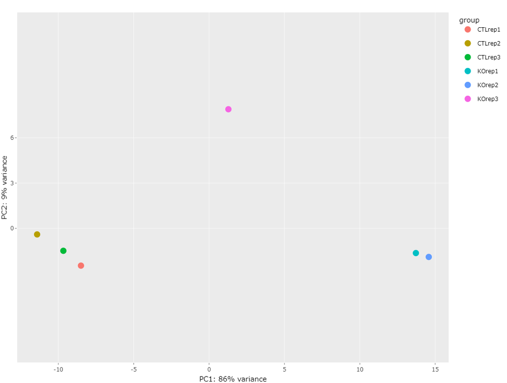

```r
knitr::include_graphics("PCA-plot.png")
```

### 3.3 After performing DE analysis, choose an appropriate FDR threshold:

At the chosen statistical threshold, there are 506 down-regulated DEGs, 38265 non-DEGs, and 739 up-regulated DEGs.

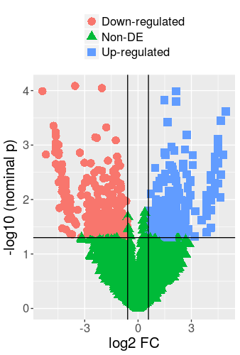

```r
knitr::include_graphics("volcano-plot.png")
```

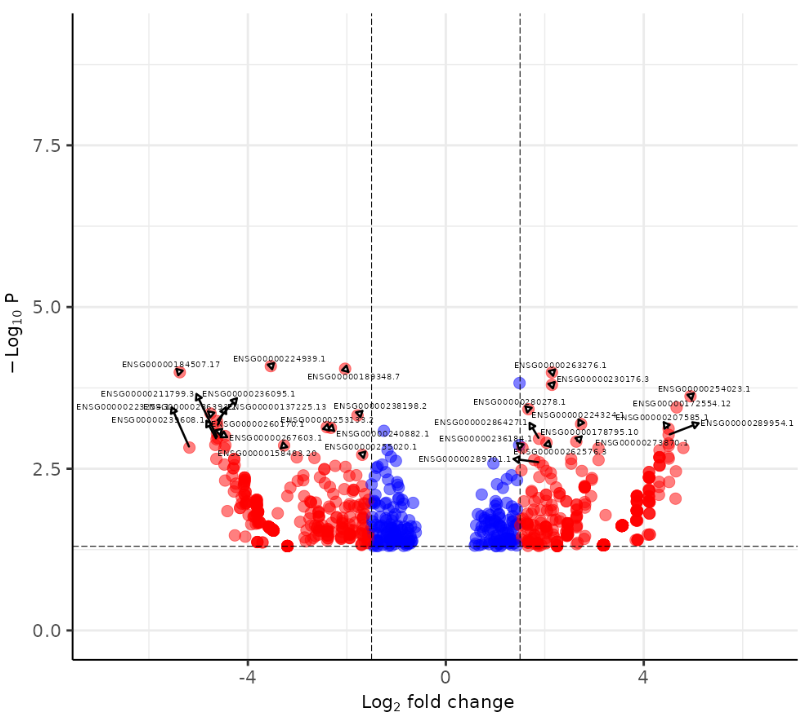

```r
knitr::include_graphics("labeled-vc.png")
```

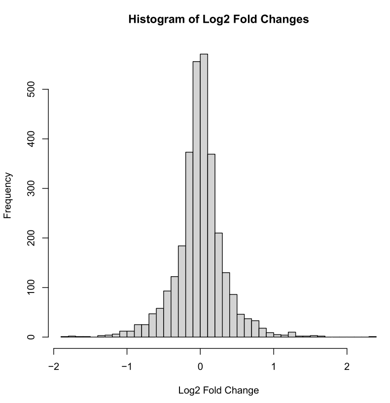

```r
knitr::include_graphics("log2fc.png")
```

#### 3.4.2 Expectations of differences:

The first approach considers all genes, potentially identifying subtle changes. The second approach focuses on statistically significant DE genes, reducing noise and complexity.

## REFERENCES

[1] Andrews, S. (2010). FastQC: A Quality Control Tool for High Throughput Sequence Data [Online]. Available online at: http://www.bioinformatics.babraham.ac.uk/projects/fastqc/ [2] Philip Ewels, Måns Magnusson, Sverker Lundin, Max Käller, MultiQC: Summarize analysis results for multiple tools and samples in a single report, Bioinformatics, Volume 32, Issue 19, October 2016, Pages 3047–3048, https://doi.org/10.1093/bioinformatics/btw354 [3] Bolger AM, Lohse M, Usadel B. Trimmomatic: a flexible trimmer for Illumina sequence data. Bioinformatics. 2014 Aug 1;30(15):2114-20. doi: 10.1093/bioinformatics/btu170. Epub 2014 Apr 1. PMID: 24695404; PMCID: PMC4103590. [4] Dobin A, Davis CA, Schlesinger F, Drenkow J, Zaleski C, Jha S, Batut P, Chaisson M, Gingeras TR. STAR: ultrafast universal RNA-seq aligner. Bioinformatics. 2013 Jan 1;29(1):15-21. doi: 10.1093/bioinformatics/bts635. Epub 2012 Oct 25. PMID: 23104886; PMCID: PMC3530905. [5] Petr Danecek, James K Bonfield, Jennifer Liddle, John Marshall, Valeriu Ohan, Martin O Pollard, Andrew Whitwham, Thomas Keane, Shane A McCarthy, Robert M Davies, Heng Li, Twelve years of SAMtools and BCFtools, GigaScience, Volume 10, Issue 2, February 2021, giab008, https://doi.org/10.1093/gigascience/giab008 [6] Zhu Q, Fisher SA, Shallcross J, Kim J. VERSE: a versatile and efficient RNA-Seq read counting tool. bioRxiv; 2016. DOI: 10.1101/053306. [7] Robinson MD, McCarthy DJ, Smyth GK. edgeR: a Bioconductor package for differential expression analysis of digital gene expression data. Bioinformatics. 2010 Jan 1;26(1):139-40. doi: 10.1093/bioinformatics/btp616. Epub 2009 Nov 11. PMID: 19910308; PMCID: PMC2796818. [8] Love MI, Huber W, Anders S. Moderated estimation of fold change and dispersion for RNA-seq data with DESeq2. Genome Biol. 2014;15(12):550. doi: 10.1186/s13059-014-0550-8. PMID: 25516281; PMCID: PMC4302049.

## SUPPLEMENTARY PLOTS

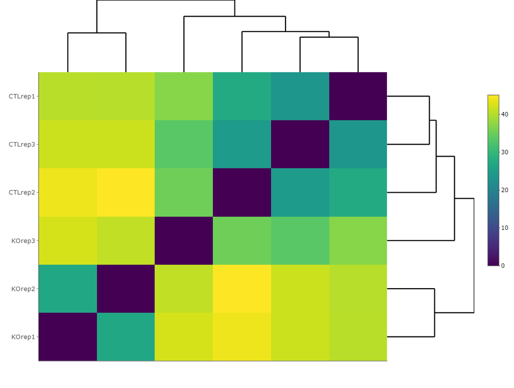

```r
knitr::include_graphics("EdgeR-sample-heatmap.png")
```

Sample Heatmap

[figure not shown]

```r
knitr::include_graphics("Heatmap.png")
```